# Spatial Ecology and Macroecology

Practical - Week 1

Florencia Grattarola

grattarola@fzp.czu.cz

[MOBI Lab](https://petrkeil.github.io/)

2026-10-05

## What are we going to see today?

1. Data types
2. Data sources
3. Open data
4. Exercise 1: explore data sources
5. Exercise 2: data download and cleaning in R (quality check)

# Data types

## 1. Data types

Data that can place a particular **taxon** in a particular **location** and **time** can take many forms, depending on:

1. What they record (*currency of the species’ distribution*)
2. How they are collected (*method*)
3. How they are made available for others (*openness*)

## 1. Data types

**Presence-only (PO) data**

- For example: records from museum and herbarium collections or citizen-science initiatives
- Characteristics: usually opportunistic, single species, spatio-temporally specific, absences are unknown

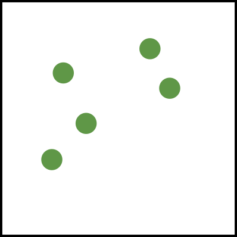

| **PROS** | **CONS** |
| --- | --- |
| huge amounts of data available, easily aggregated | often without details of effort/method, wide variation in data quality |

## 1. Data types

**Presence-absence (PA) data**

- For example: data from checklists, inventories, atlases, acoustic sensors, DNA sampling, or camera-trap surveys
- Characteristics: multiple species, spatio-temporally specific, report searches that did not find the species (absences)

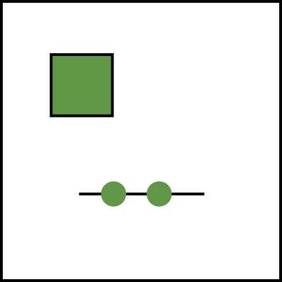

| **PROS** | **CONS** |
| --- | --- |
| absences are informative, area and effort are measured | less abundant (too time-consuming), methods are species-specific |

## 1. Data types

**Repeated surveys**

- For example: monitoring schemes, repeated atlas projects
- Characteristics: multiple species, over time, spatially defined, use a standardized protocol

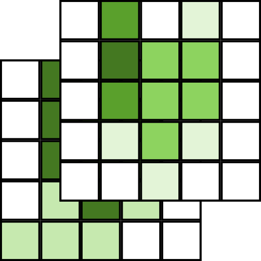

| **PROS** | **CONS** |
| --- | --- |
| standardised protocols, multiple points in time | expensive, geographically restricted, usually temporally too |

## 1. Data types

**Range-maps**

- outlines of species distributions, IUCN ranges, field guides
- single species, expert-drawn

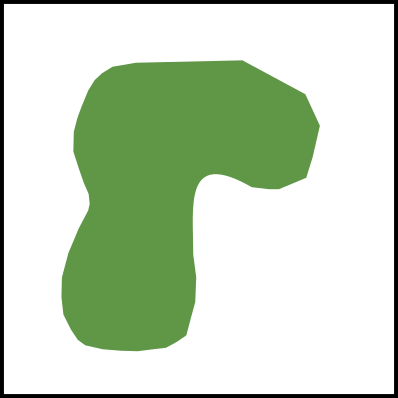

| **PROS** | **CONS** |
| --- | --- |
| rough estimates of the outer boundaries of areas within which species are likely to occur | large spatial and temporal uncertainties |

## 1. Data types

Data can also be defined by **how** they were collected.

## 1. Data types

**Structured**

- clear survey design (location, target) and standardised sampling protocol
- site selection: preselected locations, sometimes stratified random
- metadata: informs about the survey methods

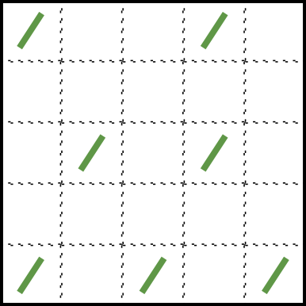

## 1. Data types

**Semi-structured**

- no survey design but *little* standardised sampling protocol
- site selection: free
- metadata: informs about the observation process and survey methods

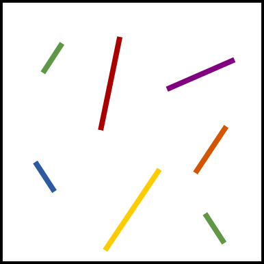

## 1. Data types

**Unstructured** (opportunistic)

- no survey design and no standardised sampling protocol
- site selection: free
- metadata: almost non

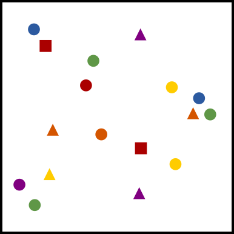

## 1. Data types

Finally, data can also be defined by how they are **made available** for others.

## 1. Data types

**Disaggregated**

- precision is high, but completeness and representativeness are low.

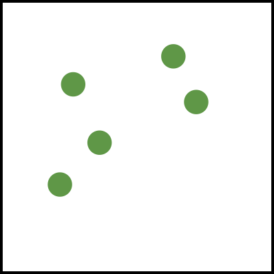

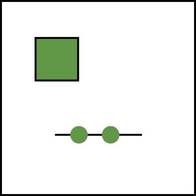

## 1. Data types

**Aggregated**

- precision is low, but completeness and representativeness are high.

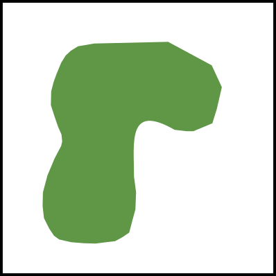

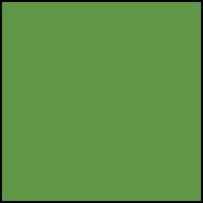

# 2. Data sources

[figure not shown]

### gbif.org

**GBIF** is an international network and data infrastructure funded by the world’s governments and aimed at providing anyone, anywhere, open access to data about all types of life on Earth.

`rgbif`: https://github.com/ropensci/rgbif

[figure not shown]

### obis.org

**OBIS** is a global open-access data and information clearing-house on marine biodiversity for science, conservation and sustainable development.

`robis`: https://github.com/iobis/robis

[figure not shown]

### [ebird.org](https://ebird.org/home)

**eBird**’s goal is to gather birdwatcher’s knowledge and experience in the form of checklists of birds, archive it, and freely share it to power new data-driven approaches to science, conservation and education.

`auk`: https://cornelllabofornithology.github.io/auk/

[figure not shown]

### [ebird.org](https://ebird.org/home)

**eBird**’s goal is to gather birdwatcher’s knowledge and experience in the form of checklists of birds, archive it, and freely share it to power new data-driven approaches to science, conservation and education.

`rebird`: https://github.com/ropensci/rebird

### inaturalist.org

**iNaturalist** is one of the world’s most popular nature apps. It allows participants to contribute observations of any organism, or traces thereof, along with associated spatio-temporal metadata.

`rinat`: https://github.com/ropensci/rinat

### observation.org

**Observation.org** is a global biodiversity platform for citizen science and monitoring, established in 2004. It mainly used in Europe.

[figure not shown]

### iucnredlist.org

**IUCN**’s (International Union for Conservation of Nature) Red List of Threatened Species has evolved to become the world’s most comprehensive information source on the global extinction risk status of animal, fungus and plant species.

`rredlist`: https://github.com/ropensci/rredlist

### mol.org

**Map of Life** assembles and integrates different sources of data describing species distributions worldwide. It is developed by the Center for Biodiversity and Global Change at Yale University.

### 10.1016/j.dib.2017.05.007

**Chorological maps for the main European woody species** is a data paper with a dataset of chorological maps for the main European tree and shrub species, put together by Giovanni Caudullo, Erik Welk, and Jesús San-Miguel-Ayanz.

[figure not shown]

### UK bto.org/our-science/projects/breeding-bird-survey

### USA usgs.gov/centers/eesc/science/north-american-breeding-bird-survey

**BBS** (Breeding Bird Survey) involves thousands of volunteer birdwatchers carrying out standardised annual bird counts on randomly-located 1-km sites. It’s part of the NBN Atlas.

[figure not shown]

### bien.nceas.ucsb.edu/bien/

**BIEN** is a network of ecologists, botanists, and computer scientists working together to document global patterns of plant diversity, function and distribution.

`rbien`: https://github.com/bmaitner/RBIEN

[figure not shown]

### [sibbr.gov.br](https://sibbr.gov.br/?lang=en_GB)

**SiBBr** (Brazilian Biodiversity Information System) is an online platform that integrates data and information about biodiversity and ecosystems from different sources, making them accessible for different uses.

**sibbr**: https://github.com/sibbr

[figure not shown]

### biotime.st-andrews.ac.uk

BioTime is an open access global database of assemblage time series for quantifying and understanding biodiversity change.

**BioTime Hub**: https://github.com/bioTIMEHub

# 3. Open Data

## 3. Open Data

**Open** means anyone can freely access, use, modify, and share for any purpose.

**Public doesn’t mean open**

The data on the internet can be public but they are not necessarily open. They can be standard, available in open formats (e.g., csv), and yet, if they don’t have a licence, by default they are closed (all rights reserved).

## 3. Open Data: Licensing

Open data are licensed under open licenses. Some examples:

[figure not shown]

**CC0**: Public domain

**CC-BY**: Attribution

[figure not shown]

**CC-BY-NC**: Attribution - Non Commercial

**CC-BY-SA**: Attribution - Share Alike

## 3. Open Data: Data standards

**Darwin Core** is the internationally agreed data standard to facilitate the sharing of information about biological diversity.

### [dwc.tdwg.org](https://dwc.tdwg.org/terms/)

[figure not shown]

`countryCode`: The standard code for the country in which the Location occurs. Recommended best practice is to use an ISO 3166-1-alpha-2 country code.

`recordedBy`: A list (concatenated and separated) of names of people, groups, or organizations responsible for recording the original Occurrence.

## 3. Open Data: Data sharing

Data that are **standardized** and have an **open licence** can be shared :)

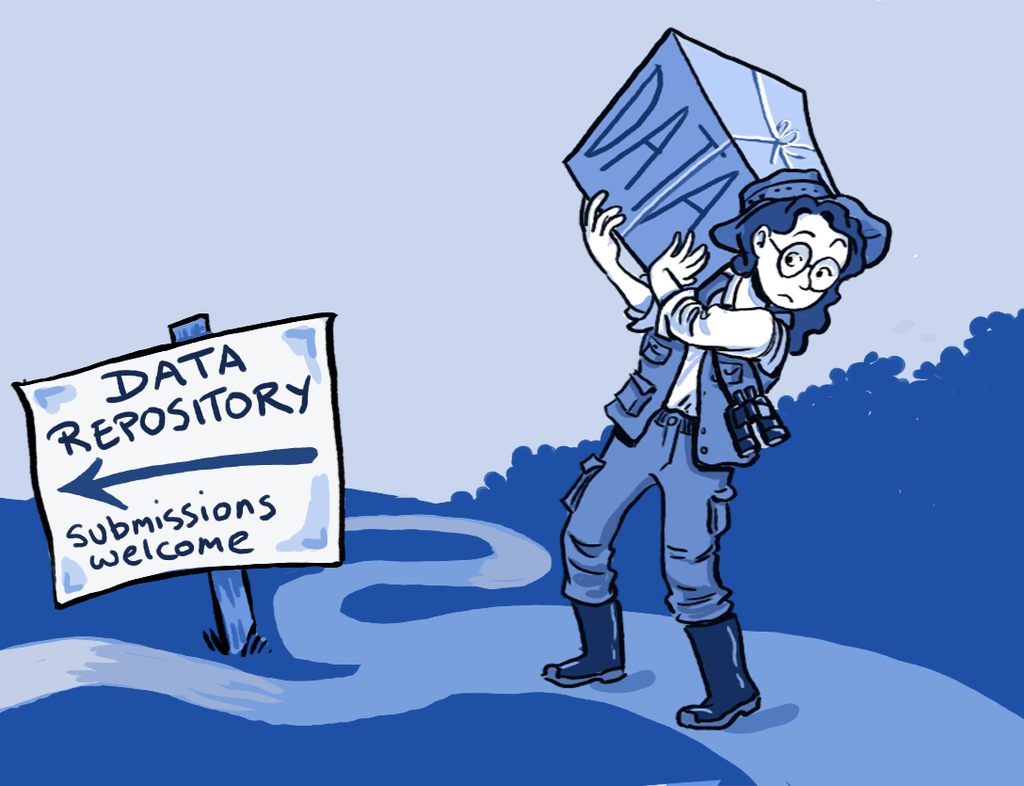

# EXERCISE 1 Explore different data sources

## Imagine you want to start a project:

Choose **one taxon** and **one data source**, and try to get distribution data.

- What kind of **data types** does the source provide?
- Which kind of **taxa** are covered by the database generally?
- How **accessible** is the data? Can anyone download it? Restrictions?
- What was your **experience**? What **issues** did you encounter while getting the data?

Should take around **5 minutes** :)  
Afterwards, we will discuss some of your examples. Please be prepared to share your experience.

# EXERCISE 2 Mammal’s of the Czech Republic

We will use the mammals of the Czech Republic as an example dataset. We will access the data through [**GBIF**](https://gbif.org) using R.

## Some preparation before starting to code

- Create a new project – you will use it for all your practical sessions (with `code` and `data` folders inside).

File > New project > New directory or Existing directory

- Download the [Quarto](https://quarto.org) Markdown document for today’s practical from: practical_week1_exercise2_STUDENTS_FILE.qmd

## 1 Install and load libraries

We will always load packages into R using the package **`pacman`**.

```r
install.packages('pacman')
```

```r
library(pacman) # load
packageVersion('pacman')
```

```
[1] '0.5.1'
```

If you attempt to load a library that is not installed, `pacman` will try to install it automatically.

## 1 Install and load libraries

We will use **`tidyverse`** for the manipulation and transformation of data.

```r
pacman::p_load(tidyverse) # Data wrangling
packageVersion('tidyverse')
```

```
[1] '2.0.0'
```

We will be using many functions from this library of package, like `filter()`, `mutate()`, and later `read_csv()`.

## 1 Install and load libraries

We will use **`rgbif`** to download data from GBIF directly into our R session.

```r
pacman::p_load(rgbif) # the GBIF R package
packageVersion('rgbif')
```

```
[1] '3.8.0'
```

## 1 Install and load libraries

We will need to get a taxon ID (`taxonKey`) for the *Mammalia* class from the GBIF backbone. For that, we will use another package called **`taxize`**.

```r
pacman::p_load(taxize)
packageVersion('taxize')
```

```
[1] '0.9.100'
```

## 1 Install and load libraries

We will use **`sf`** to work with spatial data.

```r
pacman::p_load(sf)
packageVersion('sf')
```

```
[1] '1.0.21'
```

## 1 Install and load libraries

We will use **`rnaturalearth`** to interact with [Natural Earth](https://www.naturalearthdata.com/) and get mapping data (e.g., countries’ polygons) into R.

```r
pacman::p_load(rnaturalearth)
packageVersion('rnaturalearth')
```

```
[1] '1.0.1'
```

## 2 Project variables

Create some variables that will be used later.

```r
taxon <- "Mammalia"
country_code <- "CZ" # Two letters ISO code for the Czech Republic
proj_crs <- 4326 # EPSG code for WGS84
```

Define the things you already know you will use later in the script. For instance, we know that we will work with **mammals** from the **Czech Republic** and that the data we will get from GBIF are in **WGS84** latitude and longitude.

## 2 Project variables

Get a taxon ID for the *Mammalia* class.

```r
taxon_key <- get_gbifid_(taxon) %>%
  bind_rows() %>% # Transform the result of get_gbifid into a dataframe
  filter(matchtype == "EXACT" & status == "ACCEPTED") %>% # Filter the dataframe by the columns "matchtype" and "status"
  pull(usagekey) # Pull the contents of the column "usagekey"

taxon_key
```

```
[1] 359
```

## 2 Project variables

Basemap of CZ to use later for plotting or checking the dataset.

```r
base_map <- rnaturalearth::ne_countries(
  scale = 10,
  type = 'countries',
  country = 'Czechia',
  returnclass = 'sf'
)
```

## 3 GBIF data download

And now we can use the function `occ_count()` to find out the **number of occurrence records** for the entire Czech Republic.

```r
occ_count(
  taxonKey = NULL,
  georeferenced = NULL,
  basisOfRecord = NULL,
  datasetKey = NULL,
  date = NULL,
  typeStatus = NULL,
  country = NULL,
  year = NULL,
  from = 2000,
  to = 2012,
  type = "count",
  publishingCountry = "US",
  protocol = NULL,
  curlopts = list()
)
```

## 3 GBIF data download

How many occurrence records are in GBIF for the entire **Czech Republic**?

```r
occ_count(country = country_code) # country code for the Czech Republic
```

```
[1] 8482911
```

And how many of those records are **mammals**?

```r
occ_count(country = country_code,
          taxonKey = taxon_key)
```

```
[1] 19608
```

After this initial exploration, we are ready to download data. Whoop!

## 3.1 CZ mammals’ GBIF data download

To do this, we will use `occ_search()`. This function has many options that correspond with fields in the GBIF database (DarwinCore terms).

```r
occ_search(
  taxonKey = NULL,
  scientificName = NULL,
  country = NULL,
  publishingCountry = NULL,
  hasCoordinate = NULL,
  typeStatus = NULL,
  recordNumber = NULL,
  lastInterpreted = NULL,
  continent = NULL,
  geometry = NULL,
  geom_big = "asis",
  geom_size = 40,
  geom_n = 10,
  recordedBy = NULL,
  recordedByID = NULL,
  identifiedByID = NULL,
  basisOfRecord = NULL,
  datasetKey = NULL,
  eventDate = NULL,
  catalogNumber = NULL,
  year = NULL,
  month = NULL,
  decimalLatitude = NULL,
  decimalLongitude = NULL,
  elevation = NULL,
  depth = NULL,
  institutionCode = NULL,
  collectionCode = NULL,
  hasGeospatialIssue = NULL,
  issue = NULL,
  search = NULL,
  mediaType = NULL,
  subgenusKey = NULL,
  repatriated = NULL,
  phylumKey = NULL,
  kingdomKey = NULL,
  classKey = NULL,
  orderKey = NULL,
  familyKey = NULL,
  genusKey = NULL,
  establishmentMeans = NULL,
  protocol = NULL,
  license = NULL,
  organismId = NULL,
  publishingOrg = NULL,
  stateProvince = NULL,
  waterBody = NULL,
  locality = NULL,
  limit = 500,
  start = 0,
  fields = "all",
  return = NULL,
  facet = NULL,
  facetMincount = NULL,
  facetMultiselect = NULL,
  skip_validate = TRUE,
  curlopts = list(),
  ...
)
```

## 3.1 CZ mammals’ GBIF data download

This is **not** the best way to download data from GBIF. The best way would be to use the function `occ_download()`, but you will need a user account for this.

For our next practical, please create an account in [GBIF.org](https://www.gbif.org) and follow the script download_mammalsCZ_data_from_GBIF.R in the **Week2_gridding_and plotting** of the **Practical_classes** folder to get these data.

## 3.1 CZ mammals’ GBIF data download

Get occurrence records of mammals from Czech Republic.

```r
occ_search(taxonKey = taxon_key,
           country = country_code)
```

```
Records found [19608]
Records returned [500]
No. unique hierarchies [42]
No. media records [500]
No. facets [0]
Args [occurrenceStatus=PRESENT, limit=500, offset=0, taxonKey=359, country=CZ,
     fields=all]
# A tibble: 500 × 110
   key        scientificName  decimalLatitude decimalLongitude issues datasetKey
   <chr>      <chr>                     <dbl>            <dbl> <chr>  <chr>
 1 5938078376 Lepus europaeu…            49.0             17.0 cdc,c… 50c9509d-…
 2 5938085935 Sciurus vulgar…            49.2             16.7 cdc,c… 50c9509d-…
 3 5938118202 Myocastor coyp…            48.9             16.6 cdc,c… 50c9509d-…
 4 5938121139 Felis catus Li…            49.1             13.4 cdc,c… 50c9509d-…
 5 5938154785 Lepus europaeu…            49.6             17.2 cdc,c… 50c9509d-…
 6 5938167099 Myocastor coyp…            50.1             14.4 cdc,c… 50c9509d-…
 7 5938186009 Capreolus capr…            48.9             14.4 cdc    50c9509d-…
 8 5938196131 Sciurus vulgar…            50.2             14.9 cdc,c… 50c9509d-…
 9 5938201523 Myocastor coyp…            50.1             14.4 cdc,c… 50c9509d-…
10 5938212962 Felis catus Li…            50.5             15.4 cdc,c… 50c9509d-…
# ℹ 490 more rows
# ℹ 104 more variables: publishingOrgKey <chr>, X.CitizenScience. <chr>,
#   installationKey <chr>, hostingOrganizationKey <chr>,
#   publishingCountry <chr>, protocol <chr>, lastCrawled <chr>,
#   lastParsed <chr>, crawlId <int>, basisOfRecord <chr>,
#   occurrenceStatus <chr>, taxonKey <int>, kingdomKey <int>, phylumKey <int>,
#   classKey <int>, orderKey <int>, familyKey <int>, genusKey <int>, …
```

By default, it will only return the first 500 records

## 3.1 CZ mammals’ GBIF data download

```r
occ_search(taxonKey = taxon_key,
           country = country_code,
            limit = 9000)
```

## 3.1 CZ mammals’ GBIF data download

Finally, we store the result in the object `mammalsCZ`. We include the option to remove common geospatial issues (e.g., zero coordinates, country coordinate mismatch, invalid coordinate, etc.).

```r
mammalsCZ <- occ_search(
  taxonKey = taxon_key, # Key 359 created previously
  country = country_code, # CZ, ISO code of the Czech Republic
  limit = 9000, # Max number of records to download
  hasGeospatialIssue = F # Only records without spatial issues
)

mammalsCZ <- mammalsCZ$data # The output of occ_search is a list with a data object inside. Here we pull the data out of the list.
```

## 4 Data exploration

Mammals occurrence records from the Czech Republic

Examine the dataset’s variables and their respective data types: Are they `numeric`, `character`, or `boolean` in nature?

```r
glimpse(mammalsCZ)
```

```
Rows: 9,000
Columns: 132
$ key                                       <chr> "5938078376", "5938085935", …
$ scientificName                            <chr> "Lepus europaeus Pallas, 177…
$ decimalLatitude                           <dbl> 48.99449, 49.21911, 48.88975…
$ decimalLongitude                          <dbl> 17.03156, 16.68447, 16.59729…
$ issues                                    <chr> "cdc,cdround", "cdc,cdround"…
$ datasetKey                                <chr> "50c9509d-22c7-4a22-a47d-8c4…
$ publishingOrgKey                          <chr> "28eb1a3f-1c15-4a95-931a-4af…
$ X.CitizenScience.                         <chr> "CitizenScience", "CitizenSc…
$ installationKey                           <chr> "997448a8-f762-11e1-a439-001…
$ hostingOrganizationKey                    <chr> "28eb1a3f-1c15-4a95-931a-4af…
$ publishingCountry                         <chr> "US", "US", "US", "US", "US"…
$ protocol                                  <chr> "DWC_ARCHIVE", "DWC_ARCHIVE"…
$ lastCrawled                               <chr> "2026-09-29T07:50:34.840+00:…
```

[output cut: 119 more lines]

Check the data output. How many rows and columns does it have?

## 4 Data exploration

Mammals occurrence records from the Czech Republic

How many records do we have?

```r
nrow(mammalsCZ)
```

```
[1] 9000
```

How many species do we have?

```r
mammalsCZ %>%
  filter(taxonRank == "SPECIES") %>%
  distinct(scientificName) %>%
  nrow()
```

```
[1] 81
```

`distinct()` is used to see unique values

## 5 Data quality

Data are not ‘good’ or ‘bad’; the quality will depend on our goal.  
Some things we can check:

- Basis of the record - the specific nature of the record (type of occurrence)
- Species names (taxonomic harmonisation)
- Spatial and temporal (accuracy / precision)

`CoordinateCleaner`: https://github.com/ropensci/CoordinateCleaner

Automated flagging of common spatial and temporal errors in data.

## 5.1 Basic data filtering

As an example of data cleaning procedures, we will check the following fields in our dataset:

- `basisOfRecord`: we want preserved specimens or observations.
- `taxonRank`: we want records at the species level.
- `coordinateUncertaintyInMeters`: we want it to be smaller than 10km.

## 5.1 Basic data filtering

- `basisOfRecord`: we want preserved specimens or observations

```r
mammalsCZ %>% distinct(basisOfRecord)
```

```
# A tibble: 2 × 1
  basisOfRecord
  <chr>
1 HUMAN_OBSERVATION
2 MACHINE_OBSERVATION
```

`distinct()` is used to see unique values

## 5.1 Basic data filtering

- `basisOfRecord`: we want preserved specimens or observations

```r
mammalsCZ %>%
  group_by(basisOfRecord) %>%
  count()
```

```
# A tibble: 2 × 2
# Groups:   basisOfRecord [2]
  basisOfRecord           n
  <chr>               <int>
1 HUMAN_OBSERVATION    8995
2 MACHINE_OBSERVATION     5
```

`group_by()` is used to group values within a variable

## 5.1 Basic data filtering

- `basisOfRecord`: we want preserved specimens or observations

Update the object by filtering over the *basisOfRecord* to keep only records that correspond to “preserved specimens” or “human observations”.

```r
mammalsCZ <- mammalsCZ %>%
  filter(basisOfRecord == "PRESERVED_SPECIMEN" |
    basisOfRecord == "HUMAN_OBSERVATION")
```

Note the use of `|` (OR) to filter the data. An alternative is `filter(basisOfRecord %in% c("PRESERVED_SPECIMEN","HUMAN_OBSERVATION"))`.

How many records do we have now?

```r
nrow(mammalsCZ)
```

```
[1] 8995
```

## 5.1 Basic data filtering

- `taxonRank`: we want records at the species level

```r
mammalsCZ %>% distinct(taxonRank)
```

```
# A tibble: 5 × 1
  taxonRank
  <chr>
1 SPECIES
2 GENUS
3 SUBSPECIES
4 FAMILY
5 ORDER
```

## 5.1 Basic data filtering

- `taxonRank`: we want records at the species level

Update the object by filtering over **taxonRank** to keep only records that correspond to the “species” level.

```r
mammalsCZ <- mammalsCZ %>%
  filter(taxonRank == 'SPECIES')
```

How many records do we have now?

```r
nrow(mammalsCZ)
```

```
[1] 8875
```

## 5.1 Basic data filtering

- `coordinateUncertaintyInMeters`: we want them to be smaller than 10km

```r
mammalsCZ %>%
  filter(coordinateUncertaintyInMeters >= 10000) %>%
  select(scientificName,
         coordinateUncertaintyInMeters,
         stateProvince)
```

```
# A tibble: 466 × 3
   scientificName                           coordinateUncertaint…¹ stateProvince
   <chr>                                                     <dbl> <chr>
 1 Felis catus Linnaeus, 1758                                26582 Plzeňský
 2 Talpa europaea Linnaeus, 1758                             26582 Plzeňský
 3 Castor fiber Linnaeus, 1758                               26582 Plzeňský
 4 Castor fiber Linnaeus, 1758                               26582 Plzeňský
 5 Myocastor coypus (Molina, 1782)                           26421 Prague
 6 Sus scrofa Linnaeus, 1758                                 26357 Ústecký
 7 Lutra lutra (Linnaeus, 1758)                              26582 Jihočeský
 8 Barbastella barbastellus (Schreber, 177…                  26454 Středočeský
 9 Spermophilus citellus (Linnaeus, 1766)                    26421 Prague
10 Sus scrofa Linnaeus, 1758                                 26357 Ústecký
# ℹ 456 more rows
# ℹ abbreviated name: ¹coordinateUncertaintyInMeters
```

## 5.1 Basic data filtering

- `coordinateUncertaintyInMeters`: we want them to be smaller than 10km

Update the object by filtering over **coordinateUncertaintyInMeters** to keep only records that have less than 10000 meters of uncertainty.

```r
mammalsCZ <- mammalsCZ %>%
  filter(coordinateUncertaintyInMeters < 10000) # keeping this
```

How many records do we have now?

```r
nrow(mammalsCZ)
```

```
[1] 6477
```

## 6 Basic maps

How are the records distributed?

We’ll get to this next week :)

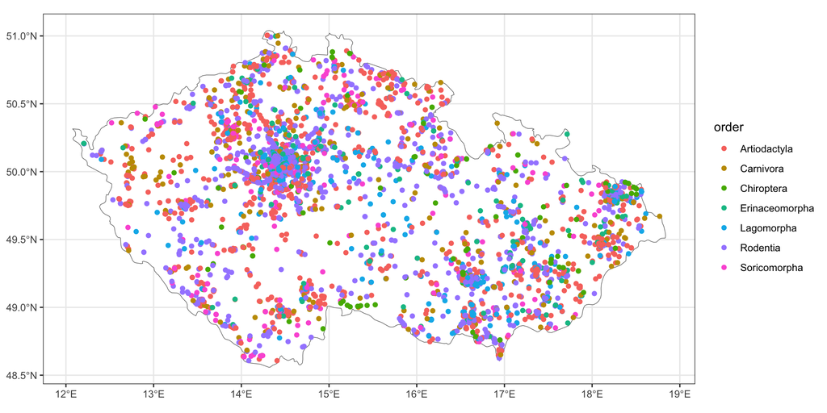

## 6 Basic maps

And finally, a simple trick to produce separate maps per order.

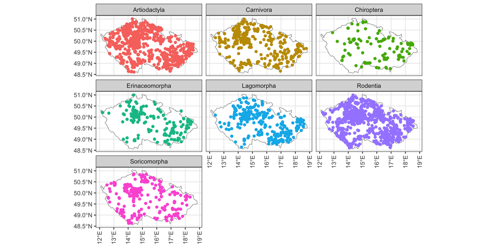

# In summary

1. Identify a data type and source
2. Check data-sharing agreements and licences
3. Download data and associated metadata
4. Check data quality (e.g., dates, spatial info, taxonomy)
5. Clean data for purpose